# Mediation analysis

Rebecca L. Knoll

last edit 04 August 2024

```r
pacman::p_load(rmarkdown, tidyverse, phyloseq, magrittr, janitor, microbiome, knitr, lubridate, naniar,  ggplot2, microViz)
#install.packages("mediation")
library(mediation) #Mediation package
library(rockchalk) #Graphing simple slopes; moderation
library(multilevel) #Sobel Test
library(bda) #Another Sobel Test option
library(gvlma) #Testing Model Assumptions
library(stargazer) #Handy regression tables
```

# 1 load data

```r
ps_full <- readRDS("/Users/rebecca/Documents/Forschung/IMMProveCF/R_analysis/rds_files/ps_IMProveCF_patients_Run1-23_18102023.rds")

ps_full_sputum <- subset_samples(ps_full, material== "Sputum")
ps_full_stool <- subset_samples(ps_full, material== "Stool")
ps_full_throat <- subset_samples(ps_full, material== "Throat")

ps_full_sputum <- tax_filter(ps_full_sputum, min_prevalence = 1) # has 632 taxa

set.seed(100)
ps_full_sputum_rar <- rarefy_even_depth(ps_full_sputum, rngseed=FALSE, sample.size=8000, replace=T, trimOTUs = T, verbose = T) # has 597 taxa
```

```
## You set `rngseed` to FALSE. Make sure you've set & recorded
##  the random seed of your session for reproducibility.
## See `?set.seed`
```

```
## ...
```

```
## 35OTUs were removed because they are no longer
## present in any sample after random subsampling
```

```
## ...
```

```r
ps_sputum_filtered <- tax_filter(ps_full_sputum, min_prevalence = 0.25) # has 101 taxa
```

```
## Proportional min_prevalence given: 0.25 --> min 15/57 samples.
```

```r
ps_sputum_filtered_rar <- tax_filter(ps_full_sputum_rar, min_prevalence = 0.25) # has 39 taxa
```

```
## Proportional min_prevalence given: 0.25 --> min 15/57 samples.
```

```r
ps_full_throat <- tax_filter(ps_full_throat, min_prevalence = 1) # removes 0s, has 2237 taxa
ps_full_throat_rar <- rarefy_even_depth(ps_full_throat, rngseed=FALSE, sample.size=5500, replace=T, trimOTUs = T, verbose = T)
```

```
## You set `rngseed` to FALSE. Make sure you've set & recorded
##  the random seed of your session for reproducibility.
## See `?set.seed`
##
## ...
```

```
## 468OTUs were removed because they are no longer
## present in any sample after random subsampling
```

```
## ...
```

```r
ps_throat_filtered <- tax_filter(ps_full_throat, min_prevalence = 0.25) # has to be prevalent in 20% of samples = 107 taxa
```

```
## Proportional min_prevalence given: 0.25 --> min 54/213 samples.
```

```r
ps_throat_filtered_rar <- tax_filter(ps_full_throat_rar, min_prevalence = 0.25) # has 70 taxa
```

```
## Proportional min_prevalence given: 0.25 --> min 54/213 samples.
```

```r
ps_full_stool <- tax_filter(ps_full_stool, min_prevalence = 1) # removes 0s, has 2341 taxa
ps_full_stool_rar <- rarefy_even_depth(ps_full_stool, rngseed=FALSE, sample.size=6500, replace=T, trimOTUs = T, verbose = T) # has 1935 taxa
```

```
## You set `rngseed` to FALSE. Make sure you've set & recorded
##  the random seed of your session for reproducibility.
## See `?set.seed`
##
## ...
```

```
## 404OTUs were removed because they are no longer
## present in any sample after random subsampling
```

```
## ...
```

```r
ps_stool_filtered <- tax_filter(ps_full_stool, min_prevalence = 0.25) # has to be prevalent in 20% of samples = 124 taxa
```

```
## Proportional min_prevalence given: 0.25 --> min 52/206 samples.
```

```r
ps_stool_filtered_rar <- tax_filter(ps_full_stool_rar, min_prevalence = 0.25) # has to be prevalent in 20% of samples = 123 taxa
```

```
## Proportional min_prevalence given: 0.25 --> min 52/206 samples.
```

```r
ps_full_relab <- transform_sample_counts(ps_full, function(x) x/sum(x))
ps_sputum_filtered_relab <- transform_sample_counts(ps_sputum_filtered, function(x) x/sum(x))
ps_throat_filtered_relab <- transform_sample_counts(ps_throat_filtered, function(x) x/sum(x))
ps_stool_filtered_relab <- transform_sample_counts(ps_stool_filtered, function(x) x/sum(x))

# extract Staphylococcus abundance

sputum_df <- psmelt(ps_sputum_filtered_relab)
sputum_df <- sputum_df %>%
  mutate(Abundance=Abundance*100) # transform relative abundance into percentages

staph_df <- sputum_df%>%
  filter(Genus=="Staphylococcus")

tabyl(staph_df, id.x,visit_cal_cor) # summary of sputum samples and to check that there is only 1 sample per patient per visit
```

| id.x | 1 | 2 | 3 | 4 | 5 | 6 | 7 | 8 | 9 |
| --- | --- | --- | --- | --- | --- | --- | --- | --- | --- |
| 11 | 1 | 1 | 1 | 0 | 0 | 1 | 0 | 0 | 1 |
| 13 | 1 | 0 | 0 | 0 | 0 | 0 | 0 | 0 | 0 |
| 15 | 1 | 0 | 0 | 0 | 0 | 0 | 0 | 0 | 0 |
| 16 | 1 | 0 | 0 | 0 | 0 | 0 | 0 | 0 | 0 |
| 17 | 1 | 0 | 0 | 0 | 0 | 0 | 0 | 0 | 0 |
| 21 | 1 | 1 | 1 | 1 | 0 | 1 | 0 | 1 | 0 |
| 24 | 1 | 0 | 0 | 1 | 0 | 0 | 0 | 0 | 0 |
| 25 | 1 | 1 | 0 | 0 | 1 | 1 | 1 | 1 | 0 |
| 26 | 1 | 1 | 0 | 0 | 0 | 0 | 1 | 1 | 0 |
| 27 | 1 | 1 | 0 | 1 | 0 | 1 | 0 | 1 | 0 |

[output cut: 9 more lines]

# 2 Mediation analysis on Staphylococcus abundance mediated by sweat chloride, dependent on ETI treatment duration (days) using`JSmediation` package, as in Morgan Essex Gespic Paper

```r
# Install and load necessary packages
#install.packages("JSmediation")
#install.packages("lme4")
library(JSmediation)
library(lme4)
# Fit the mixed-effects models
fitM_staph <- lmer(chlorid_mmol_cl_l ~ delta_ETI_merged + sex + age_y + (1 | id.x), data = staph_df)
fitY_staph <- lmer(Abundance ~ delta_ETI_merged + chlorid_mmol_cl_l + sex + age_y + (1 | id.x), data = staph_df)

# Perform the mediation analysis using mdt_simple
mediation_result <- mdt_simple(staph_df, # data set
                               delta_ETI_merged, # predictor
                               Abundance, # outcome
                               chlorid_mmol_cl_l) # mediator
mediation_result
```

```
## Test of mediation (simple mediation)
## ==============================================
##
## Variables:
##
## - IV: delta_ETI_merged
## - DV: Abundance
## - M: chlorid_mmol_cl_l
##
## Paths:
##
## ====  ==============  =====  ======================
## Path  Point estimate     SE  APA
## ====  ==============  =====  ======================
## a             -0.072  0.015  t(31) = 4.82, p < .001
## b              0.331  0.150  t(30) = 2.21, p = .035
## c             -0.029  0.008  t(55) = 3.64, p < .001
## c'            -0.010  0.017  t(30) = 0.59, p = .561
## ====  ==============  =====  ======================
##
## Indirect effect index:
##
## Indirect effect index is not computed by default.
## Please use add_index() to compute it.
##
## Fitted models:
##
## - X -> Y
## - X -> M
## - X + M -> Y
```

```r
med_output <- add_index(mediation_result)
med_output$type
```

```
## [1] "simple mediation"
```

```r
med_output$method
```

```
## [1] "joint significant"
```

```r
med_output$params
```

```
## $IV
## [1] "delta_ETI_merged"
##
## $DV
## [1] "Abundance"
##
## $M
## [1] "chlorid_mmol_cl_l"
```

```r
med_output$paths
```

```
## $a
## $a$point_estimate
## [1] -0.07241581
##
## $a$se
## [1] 0.01501267
##
## $a$APA
## [1] "t(31) = 4.82, p < .001"
##
##
## $b
## $b$point_estimate
## [1] 0.331141
##
## $b$se
## [1] 0.1500046
##
## $b$APA
## [1] "t(30) = 2.21, p = .035"
##
##
## $c
## $c$point_estimate
## [1] -0.02906967
##
## $c$se
## [1] 0.007989211
##
## $c$APA
## [1] "t(55) = 3.64, p < .001"
##
##
## $`c'`
## $`c'`$point_estimate
## [1] -0.0097406
##
## $`c'`$se
## [1] 0.01658947
##
## $`c'`$APA
## [1] "t(30) = 0.59, p = .561"
```

```r
med_output$indirect_index
```

```
## [1] TRUE
```

```r
med_output$indirect_index_infos
```

```
## - type: Indirect effect
## - point estimate: -0.024
## - confidence interval:
##   - method: Monte Carlo (5000 iterations)
##   - level: 0.05
##   - CI: [-0.0499; -0.00196]
```

```r
med_output$js_models
```

```
## $`X -> Y`
##
## Call:
## lm(formula = .x, data = data)
##
## Coefficients:
##      (Intercept)  delta_ETI_merged
##         14.08219          -0.02907
##
##
## $`X -> M`
##
## Call:
## lm(formula = .x, data = data)
##
## Coefficients:
##      (Intercept)  delta_ETI_merged
##         76.07633          -0.07242
##
##
## $`X + M -> Y`
##
## Call:
## lm(formula = .x, data = data)
##
## Coefficients:
##       (Intercept)   delta_ETI_merged  chlorid_mmol_cl_l
##         -7.994679          -0.009741           0.331141
```

```r
# Summarize the mediation analysis
summary(mediation_result)
```

```
##                      Length Class      Mode
## type                   1    -none-     character
## method                 1    -none-     character
## params                 3    -none-     list
## paths                  4    -none-     list
## indirect_index         1    -none-     logical
## indirect_index_infos   0    -none-     NULL
## js_models              3    -none-     list
## data                 278    data.frame list
```

Interpretation of mediation analysis using the `mdt_simple()` function from the `JSmediation` package, lets break down the key components:

### 2.0.1 Variables:

- **IV (Independent Variable)**: `delta_ETI_merged`
- **DV (Dependent Variable)**: `Abundance`
- **M (Mediator)**: `chlorid_mmol_cl_l`

### 2.0.2 Paths:

- **Path a (IV to Mediator)**:
  - Point Estimate: -0.07241581
  - Standard Error: 0.01501267
  - t(31) = 4.82, p < .001
  - Interpretation: There is a significant negative effect of `delta_ETI_merged` on `chlorid_mmol_cl_l`. This means that as `delta_ETI_merged` increases, `chlorid_mmol_cl_l` decreases significantly.
- **Path b (Mediator to DV, controlling for IV)**:
  - Point Estimate: 0.331141
  - Standard Error: 0.1500046
  - t(30) = 2.21, p = .035
  - Interpretation: There is a significant positive effect of `chlorid_mmol_cl_l` on `Abundance`, controlling for `delta_ETI_merged`. This means that as `chlorid_mmol_cl_l` increases, `Abundance` increases significantly.
- **Path c (Total effect of IV on DV)**:
  - Point Estimate: -0.02906967
  - Standard Error: 0.007989211
  - t(55) = 3.64, p < .001
  - Interpretation: There is a significant negative total effect of `delta_ETI_merged` on `Abundance`. This means that as `delta_ETI_merged` increases, `Abundance` decreases significantly.
- **Path c (Direct effect of IV on DV, controlling for Mediator)**:
  - Point Estimate: -0.0097406
  - Standard Error: 0.01658947
  - t(30) = 0.59, p = .561
  - Interpretation: The direct effect of `delta_ETI_merged` on `Abundance`, controlling for `chlorid_mmol_cl_l`, is not significant. This suggests that the relationship between `delta_ETI_merged` and `Abundance` is largely mediated by `chlorid_mmol_cl_l`.

### 2.0.4 Summary:

- **Significant Indirect Effect**: The mediation analysis reveals that `chlorid_mmol_cl_l` significantly mediates the effect of `delta_ETI_merged` on `Abundance`. This is supported by the significant paths a and b, as well as the significant indirect effect.
- **Non-significant Direct Effect**: The direct effect of `delta_ETI_merged` on `Abundance`, controlling for `chlorid_mmol_cl_l`, is not significant. This suggests that the effect of `delta_ETI_merged` on `Abundance` is primarily through its effect on `chlorid_mmol_cl_l`.

### 2.0.5 Reporting the Results

The mediation analysis examined whether `chlorid_mmol_cl_l` mediated the relationship between `delta_ETI_merged` and `Abundance`.

The analysis revealed a significant negative total effect of `delta_ETI_merged` on `Abundance` (c path: β = -0.029, SE = 0.008, t(55) = 3.64, p < .001). The direct effect of `delta_ETI_merged` on `Abundance`, controlling for `chlorid_mmol_cl_l`, was not significant (c`'` path: β = -0.010, SE = 0.017, t(30) = 0.59, p = .561).

The effect of `delta_ETI_merged` on `chlorid_mmol_cl_l` was significant and negative (a path: β = -0.072, SE = 0.015, t(31) = 4.82, p < .001). Additionally, the effect of `chlorid_mmol_cl_l` on `Abundance`, controlling for `delta_ETI_merged`, was significant and positive (b path: β = 0.331, SE = 0.150, t(30) = 2.21, p = .035).

These results suggest that the impact of `delta_ETI_merged` on `Abundance` is largely mediated by changes in `chlorid_mmol_cl_l`, highlighting the important role of `chlorid_mmol_cl_l` in this relationship.

# 3 Mediation analysis with the mediate package on Staphylococcus abundance mediated by sweat chloride, dependent on ETI treatment duration (days)

```r
# perform mediation analysis for Staphylococcus
fitM_staph <- lm(staph_df$chlorid_mmol_cl_l ~ staph_df$delta_ETI_merged + staph_df$sex + staph_df$age_y)   ####### M: sweat chloride predicting X: tt time
fitY_staph <- lm(staph_df$Abundance ~ staph_df$delta_ETI_merged + staph_df$chlorid_mmol_cl_l + staph_df$sex + staph_df$age_y)
                 ###### X: tt time and M: sweat chloride predicting Y:Staph abundance

summary(fitM_staph)
```

```
##
## Call:
## lm(formula = staph_df$chlorid_mmol_cl_l ~ staph_df$delta_ETI_merged +
##     staph_df$sex + staph_df$age_y)
##
## Residuals:
##     Min      1Q  Median      3Q     Max
## -54.824 -10.304   1.312  12.370  35.029
##
## Coefficients:
##                           Estimate Std. Error t value Pr(>|t|)
## (Intercept)               69.09196   11.23288   6.151 1.05e-06 ***
## staph_df$delta_ETI_merged -0.06696    0.01448  -4.624 7.21e-05 ***
## staph_df$sex2             17.80561    8.48526   2.098   0.0447 *
## staph_df$age_y            -0.04674    0.38476  -0.121   0.9042
## ---
## Signif. codes:  0 '***' 0.001 '**' 0.01 '*' 0.05 '.' 0.1 ' ' 1
##
## Residual standard error: 21.01 on 29 degrees of freedom
##   (24 observations deleted due to missingness)
## Multiple R-squared:  0.5178, Adjusted R-squared:  0.4679
## F-statistic: 10.38 on 3 and 29 DF,  p-value: 8.336e-05
```

```r
summary(fitY_staph)
```

```
##
## Call:
## lm(formula = staph_df$Abundance ~ staph_df$delta_ETI_merged +
##     staph_df$chlorid_mmol_cl_l + staph_df$sex + staph_df$age_y)
##
## Residuals:
##     Min      1Q  Median      3Q     Max
## -26.229 -12.484  -1.041   7.083  49.069
##
## Coefficients:
##                             Estimate Std. Error t value Pr(>|t|)
## (Intercept)                -2.634242  15.048878  -0.175   0.8623
## staph_df$delta_ETI_merged  -0.006579   0.016846  -0.391   0.6991
## staph_df$chlorid_mmol_cl_l  0.397641   0.163877   2.426   0.0219 *
## staph_df$sex2              -4.925148   8.036686  -0.613   0.5449
## staph_df$age_y             -0.267543   0.339641  -0.788   0.4375
## ---
## Signif. codes:  0 '***' 0.001 '**' 0.01 '*' 0.05 '.' 0.1 ' ' 1
##
## Residual standard error: 18.54 on 28 degrees of freedom
##   (24 observations deleted due to missingness)
## Multiple R-squared:   0.33,  Adjusted R-squared:  0.2343
## F-statistic: 3.448 on 4 and 28 DF,  p-value: 0.02064
```

```r
gvlma(fitM_staph)
```

```
##
## Call:
## lm(formula = staph_df$chlorid_mmol_cl_l ~ staph_df$delta_ETI_merged +
##     staph_df$sex + staph_df$age_y)
##
## Coefficients:
##               (Intercept)  staph_df$delta_ETI_merged
##                  69.09196                   -0.06696
##             staph_df$sex2             staph_df$age_y
##                  17.80561                   -0.04674
##
##
## ASSESSMENT OF THE LINEAR MODEL ASSUMPTIONS
## USING THE GLOBAL TEST ON 4 DEGREES-OF-FREEDOM:
## Level of Significance =  0.05
##
## Call:
##  gvlma(x = fitM_staph)
##
##                     Value p-value                Decision
## Global Stat        5.7022  0.2225 Assumptions acceptable.
## Skewness           2.5325  0.1115 Assumptions acceptable.
## Kurtosis           0.2561  0.6128 Assumptions acceptable.
## Link Function      2.3606  0.1244 Assumptions acceptable.
## Heteroscedasticity 0.5529  0.4571 Assumptions acceptable.
```

```r
gvlma(fitY_staph)
```

```
##
## Call:
## lm(formula = staph_df$Abundance ~ staph_df$delta_ETI_merged +
##     staph_df$chlorid_mmol_cl_l + staph_df$sex + staph_df$age_y)
##
## Coefficients:
##                (Intercept)   staph_df$delta_ETI_merged
##                  -2.634242                   -0.006579
## staph_df$chlorid_mmol_cl_l               staph_df$sex2
##                   0.397641                   -4.925148
##             staph_df$age_y
##                  -0.267543
##
##
## ASSESSMENT OF THE LINEAR MODEL ASSUMPTIONS
## USING THE GLOBAL TEST ON 4 DEGREES-OF-FREEDOM:
## Level of Significance =  0.05
##
## Call:
##  gvlma(x = fitY_staph)
##
##                     Value   p-value                   Decision
## Global Stat        24.666 5.871e-05 Assumptions NOT satisfied!
## Skewness            6.885 8.691e-03 Assumptions NOT satisfied!
## Kurtosis            3.132 7.678e-02    Assumptions acceptable.
## Link Function       2.946 8.611e-02    Assumptions acceptable.
## Heteroscedasticity 11.704 6.238e-04 Assumptions NOT satisfied!
```

```r
fitMed_staph <- mediate(fitM_staph, fitY_staph, treat="staph_df$delta_ETI_merged", mediator="staph_df$chlorid_mmol_cl_l")
summary(fitMed_staph)
```

```
##
## Causal Mediation Analysis
##
## Quasi-Bayesian Confidence Intervals
##
##                Estimate 95% CI Lower 95% CI Upper p-value
## ACME           -0.02673     -0.05217         0.00   0.020 *
## ADE            -0.00634     -0.03888         0.02   0.688
## Total Effect   -0.03307     -0.06018        -0.01   0.018 *
## Prop. Mediated  0.78969      0.05381         3.12   0.038 *
## ---
## Signif. codes:  0 '***' 0.001 '**' 0.01 '*' 0.05 '.' 0.1 ' ' 1
##
## Sample Size Used: 33
##
##
## Simulations: 1000
```

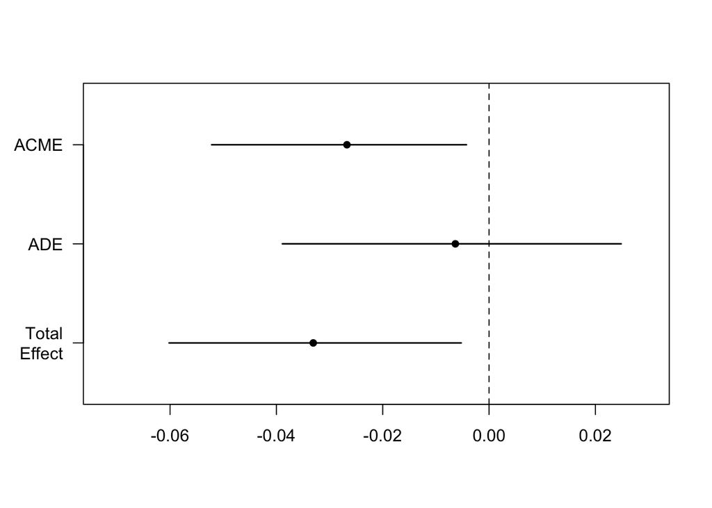

```r
plot(fitMed_staph)
```

Mediation Analysis Overview

In a mediation analysis, we are interested in understanding whether the effect of an independent variable (treatment) on a dependent variable (outcome) is mediated through a third variable (mediator).

Here, the variables are:

```
Treatment (X): staph_df$delta_ETI_merged (tt time)
Mediator (M): staph_df$chlorid_mmol_cl_l (sweat chloride)
Outcome (Y): staph_df$Abundance (Staphylococcus abundance)
```

Fit Models

```
Mediator Model (fitM_staph):
Mediator (M)=β0+β1⋅Treatment (X)+β2⋅sex+β3⋅age
Mediator (M)=β0+β1⋅Treatment (X)+β2⋅sex+β3⋅age

This model examines how the treatment (tt time) affects the mediator (sweat chloride).

Outcome Model (fitY_staph):
Outcome (Y)=γ0+γ1⋅Treatment (X)+γ2⋅Mediator (M)+γ3⋅sex+γ4⋅age
Outcome (Y)=γ0+γ1⋅Treatment (X)+γ2⋅Mediator (M)+γ3⋅sex+γ4⋅age

This model examines how both the treatment (tt time) and the mediator (sweat chloride) affect the outcome (Staphylococcus abundance).
```

Mediation Analysis Results

The mediate function combines the results from these models to decompose the total effect of the treatment on the outcome into:

```
ACME (Average Causal Mediation Effect): The effect of the treatment on the outcome that is mediated through the mediator.
ADE (Average Direct Effect): The effect of the treatment on the outcome that is not mediated through the mediator.
Total Effect: The combined effect of ACME and ADE.
Proportion Mediated: The proportion of the total effect that is mediated through the mediator.
```

Interpretation of Results

[output not shown]

Conclusion

The results suggest that the effect of tt time on Staphylococcus abundance is largely mediated through sweat chloride levels. This means that changes in sweat chloride due to the treatment (tt time) play a crucial role in influencing Staphylococcus abundance. The direct effect of the treatment on Staphylococcus abundance, independent of sweat chloride levels, is not significant.

# 4 revers the mediation effect for confirmation

```r
# perform mediation analysis for Staphylococcus
fitM_staph_r <- lm(staph_df$delta_ETI_merged ~ staph_df$chlorid_mmol_cl_l + staph_df$sex + staph_df$age_y)   ####### M: sweat chloride predicting X: tt time
fitY_staph <- lm(staph_df$Abundance ~ staph_df$delta_ETI_merged + staph_df$chlorid_mmol_cl_l + staph_df$sex + staph_df$age_y)
                 ###### X: tt time and M: sweat chloride predicting Y:Staph abundance

summary(fitM_staph_r)
```

```
##
## Call:
## lm(formula = staph_df$delta_ETI_merged ~ staph_df$chlorid_mmol_cl_l +
##     staph_df$sex + staph_df$age_y)
##
## Residuals:
##     Min      1Q  Median      3Q     Max
## -407.51 -113.35   -5.76   52.29  521.68
##
## Coefficients:
##                            Estimate Std. Error t value Pr(>|t|)
## (Intercept)                518.9385   135.0298   3.843 0.000611 ***
## staph_df$chlorid_mmol_cl_l  -6.3372     1.3706  -4.624 7.21e-05 ***
## staph_df$sex2               54.2392    88.0168   0.616 0.542545
## staph_df$age_y               0.7831     3.7412   0.209 0.835656
## ---
## Signif. codes:  0 '***' 0.001 '**' 0.01 '*' 0.05 '.' 0.1 ' ' 1
##
## Residual standard error: 204.4 on 29 degrees of freedom
##   (24 observations deleted due to missingness)
## Multiple R-squared:  0.4418, Adjusted R-squared:  0.3841
## F-statistic: 7.652 on 3 and 29 DF,  p-value: 0.0006482
```

```r
summary(fitY_staph)
```

```
##
## Call:
## lm(formula = staph_df$Abundance ~ staph_df$delta_ETI_merged +
##     staph_df$chlorid_mmol_cl_l + staph_df$sex + staph_df$age_y)
##
## Residuals:
##     Min      1Q  Median      3Q     Max
## -26.229 -12.484  -1.041   7.083  49.069
##
## Coefficients:
##                             Estimate Std. Error t value Pr(>|t|)
## (Intercept)                -2.634242  15.048878  -0.175   0.8623
## staph_df$delta_ETI_merged  -0.006579   0.016846  -0.391   0.6991
## staph_df$chlorid_mmol_cl_l  0.397641   0.163877   2.426   0.0219 *
## staph_df$sex2              -4.925148   8.036686  -0.613   0.5449
## staph_df$age_y             -0.267543   0.339641  -0.788   0.4375
## ---
## Signif. codes:  0 '***' 0.001 '**' 0.01 '*' 0.05 '.' 0.1 ' ' 1
##
## Residual standard error: 18.54 on 28 degrees of freedom
##   (24 observations deleted due to missingness)
## Multiple R-squared:   0.33,  Adjusted R-squared:  0.2343
## F-statistic: 3.448 on 4 and 28 DF,  p-value: 0.02064
```

```r
gvlma(fitM_staph_r)
```

```
##
## Call:
## lm(formula = staph_df$delta_ETI_merged ~ staph_df$chlorid_mmol_cl_l +
##     staph_df$sex + staph_df$age_y)
##
## Coefficients:
##                (Intercept)  staph_df$chlorid_mmol_cl_l
##                   518.9385                     -6.3372
##              staph_df$sex2              staph_df$age_y
##                    54.2392                      0.7831
##
##
## ASSESSMENT OF THE LINEAR MODEL ASSUMPTIONS
## USING THE GLOBAL TEST ON 4 DEGREES-OF-FREEDOM:
## Level of Significance =  0.05
##
## Call:
##  gvlma(x = fitM_staph_r)
##
##                     Value p-value                   Decision
## Global Stat        9.3625 0.05265    Assumptions acceptable.
## Skewness           4.5005 0.03389 Assumptions NOT satisfied!
## Kurtosis           2.4131 0.12033    Assumptions acceptable.
## Link Function      0.8422 0.35878    Assumptions acceptable.
## Heteroscedasticity 1.6068 0.20495    Assumptions acceptable.
```

```r
gvlma(fitY_staph)
```

```
##
## Call:
## lm(formula = staph_df$Abundance ~ staph_df$delta_ETI_merged +
##     staph_df$chlorid_mmol_cl_l + staph_df$sex + staph_df$age_y)
##
## Coefficients:
##                (Intercept)   staph_df$delta_ETI_merged
##                  -2.634242                   -0.006579
## staph_df$chlorid_mmol_cl_l               staph_df$sex2
##                   0.397641                   -4.925148
##             staph_df$age_y
##                  -0.267543
##
##
## ASSESSMENT OF THE LINEAR MODEL ASSUMPTIONS
## USING THE GLOBAL TEST ON 4 DEGREES-OF-FREEDOM:
## Level of Significance =  0.05
##
## Call:
##  gvlma(x = fitY_staph)
##
##                     Value   p-value                   Decision
## Global Stat        24.666 5.871e-05 Assumptions NOT satisfied!
## Skewness            6.885 8.691e-03 Assumptions NOT satisfied!
## Kurtosis            3.132 7.678e-02    Assumptions acceptable.
## Link Function       2.946 8.611e-02    Assumptions acceptable.
## Heteroscedasticity 11.704 6.238e-04 Assumptions NOT satisfied!
```

```r
fitMed_staph_r <- mediate(fitM_staph_r, fitY_staph, treat= "staph_df$chlorid_mmol_cl_l", mediator= "staph_df$delta_ETI_merged")
summary(fitMed_staph_r)
```

```
##
## Causal Mediation Analysis
##
## Quasi-Bayesian Confidence Intervals
##
##                Estimate 95% CI Lower 95% CI Upper p-value
## ACME             0.0431      -0.1706         0.25   0.676
## ADE              0.3920       0.0756         0.72   0.022 *
## Total Effect     0.4351       0.2046         0.68  <2e-16 ***
## Prop. Mediated   0.1025      -0.4519         0.72   0.676
## ---
## Signif. codes:  0 '***' 0.001 '**' 0.01 '*' 0.05 '.' 0.1 ' ' 1
##
## Sample Size Used: 33
##
##
## Simulations: 1000
```

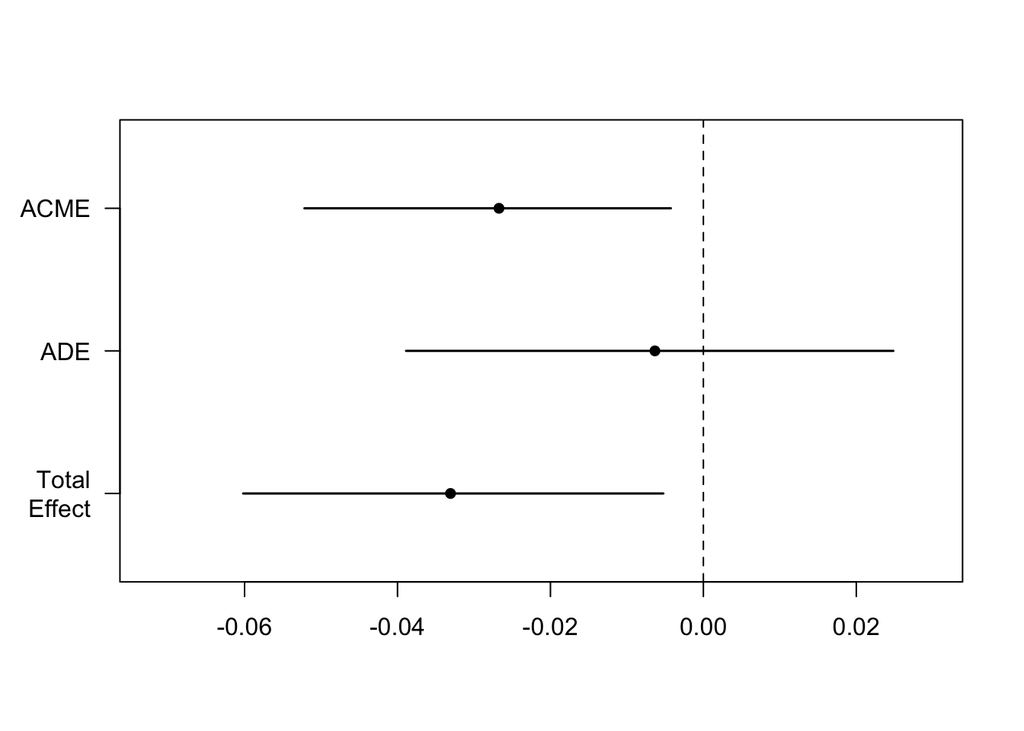

```r
plot(fitMed_staph)
```

# 5 add random effects for repeated measures:

```r
# perform mediation analysis for Staphylococcus
fit.totaleffect <- lmer(Abundance ~ delta_ETI_merged + (1|id.x) + sex + age_y, data = staph_df) # this is computed for all sputum samples (N=57) and not truely needed for the subsequent analysis
fit.mediator <- lmer(chlorid_mmol_cl_l ~ delta_ETI_merged + (1|id.x) + sex + age_y, data = staph_df)
fitY<- lmer(Abundance ~ delta_ETI_merged + (1|id.x) + chlorid_mmol_cl_l + sex + age_y, data = staph_df)

summary(fit.totaleffect)
```

```
## Linear mixed model fit by REML ['lmerMod']
## Formula: Abundance ~ delta_ETI_merged + (1 | id.x) + sex + age_y
##    Data: staph_df
##
## REML criterion at convergence: 472.6
##
## Scaled residuals:
##     Min      1Q  Median      3Q     Max
## -1.0909 -0.6375 -0.2729  0.2866  3.5497
##
## Random effects:
##  Groups   Name        Variance Std.Dev.
##  id.x     (Intercept)  16.42    4.052
##  Residual             234.57   15.316
## Number of obs: 57, groups:  id.x, 19
##
## Fixed effects:
##                   Estimate Std. Error t value
## (Intercept)      17.240124   7.330272   2.352
## delta_ETI_merged -0.028916   0.008219  -3.518
## sex2             -0.113150   5.088109  -0.022
## age_y            -0.095997   0.241987  -0.397
##
## Correlation of Fixed Effects:
##             (Intr) d_ETI_ sex2
## dlt_ETI_mrg -0.215
## sex2        -0.016  0.208
## age_y       -0.851 -0.112 -0.345
```

```r
summary(fit.mediator)
```

```
## Linear mixed model fit by REML ['lmerMod']
## Formula: chlorid_mmol_cl_l ~ delta_ETI_merged + (1 | id.x) + sex + age_y
##    Data: staph_df
##
## REML criterion at convergence: 286
##
## Scaled residuals:
##      Min       1Q   Median       3Q      Max
## -2.37293 -0.47112  0.02978  0.55453  1.39866
##
## Random effects:
##  Groups   Name        Variance Std.Dev.
##  id.x     (Intercept)  94.59    9.726
##  Residual             350.69   18.727
## Number of obs: 33, groups:  id.x, 18
##
## Fixed effects:
##                  Estimate Std. Error t value
## (Intercept)      70.60303   12.04290   5.863
## delta_ETI_merged -0.06775    0.01366  -4.960
## sex2             16.12357    9.13128   1.766
## age_y            -0.02820    0.40961  -0.069
##
## Correlation of Fixed Effects:
##             (Intr) d_ETI_ sex2
## dlt_ETI_mrg -0.156
## sex2         0.042  0.141
## age_y       -0.860 -0.052 -0.415
```

```r
summary(fitY)
```

```
## Linear mixed model fit by REML ['lmerMod']
## Formula: Abundance ~ delta_ETI_merged + (1 | id.x) + chlorid_mmol_cl_l +
##     sex + age_y
##    Data: staph_df
##
## REML criterion at convergence: 278.9
##
## Scaled residuals:
##      Min       1Q   Median       3Q      Max
## -1.13413 -0.51388 -0.08702  0.49637  2.11958
##
## Random effects:
##  Groups   Name        Variance Std.Dev.
##  id.x     (Intercept) 176.8    13.30
##  Residual             206.4    14.37
## Number of obs: 33, groups:  id.x, 18
##
## Fixed effects:
##                     Estimate Std. Error t value
## (Intercept)       -1.474e+01  1.634e+01  -0.902
## delta_ETI_merged   3.694e-04  1.560e-02   0.024
## chlorid_mmol_cl_l  5.415e-01  1.580e-01   3.426
## sex2              -3.529e+00  9.297e+00  -0.380
## age_y             -2.898e-01  3.987e-01  -0.727
##
## Correlation of Fixed Effects:
##             (Intr) d_ETI_ chl___ sex2
## dlt_ETI_mrg -0.544
## chlrd_mml__ -0.695  0.698
## sex2         0.161 -0.101 -0.255
## age_y       -0.616 -0.033  0.007 -0.365
```

```r
fitMed_staph <- mediate(fit.mediator, fitY, treat= "delta_ETI_merged", mediator=  "chlorid_mmol_cl_l")
summary(fitMed_staph)
```

```
##
## Causal Mediation Analysis
##
## Quasi-Bayesian Confidence Intervals
##
## Mediator Groups: id.x
##
## Outcome Groups: id.x
##
## Output Based on Overall Averages Across Groups
##
##                 Estimate 95% CI Lower 95% CI Upper p-value
## ACME           -0.036786    -0.065473        -0.01   0.002 **
## ADE             0.000244    -0.032178         0.03   0.962
## Total Effect   -0.036542    -0.062927        -0.01   0.008 **
## Prop. Mediated  1.026799     0.339401         3.27   0.010 **
## ---
## Signif. codes:  0 '***' 0.001 '**' 0.01 '*' 0.05 '.' 0.1 ' ' 1
##
## Sample Size Used: 33
##
##
## Simulations: 1000
```

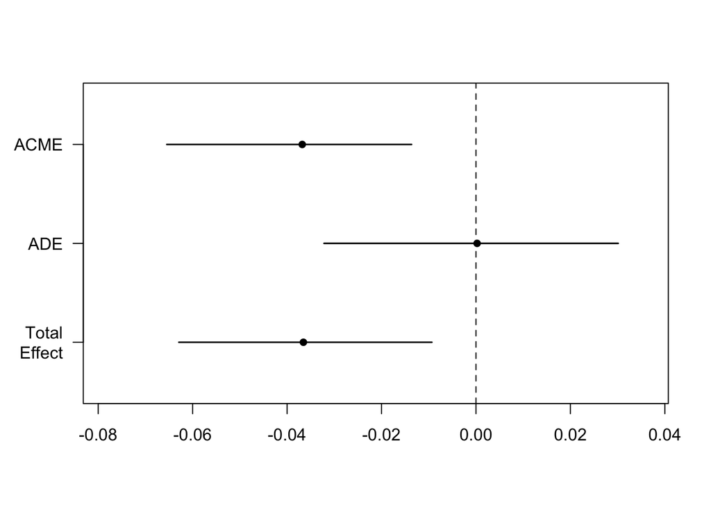

```r
plot(fitMed_staph)
```

# function for mediation analysis with repeated measures

```r
library(lme4)
library(mediation)

# Define the function for mediation analysis
perform_mediation_analysis <- function(data, mediator, outcome, predictor, id_var, covariates) {
  # Construct the covariates string
  covariates_str <- paste(covariates, collapse = " + ")

  # Construct formulas for the models
  mediator_formula <- as.formula(paste(mediator, "~", predictor, "+ (1|", id_var, ") +", covariates_str))
  outcome_formula <- as.formula(paste(outcome, "~", predictor, "+ (1|", id_var, ") +", mediator, "+", covariates_str))

  # Fit the models
  fit.mediator <- lmer(mediator_formula, data = data)
  fitY <- lmer(outcome_formula, data = data)

  # Print summaries of the models
  print(summary(fit.mediator))
  print(summary(fitY))

  # Perform mediation analysis
  fitMed <- mediate(fit.mediator, fitY, treat = predictor, mediator = mediator)

  # Print summary and plot the results
  print(summary(fitMed))
  plot(fitMed)

  return(fitMed)
}
```

# 6 Staphylococcus abundance in Sputum, mediated by sweat chloride, corrected for id as repeated measure

```r
# Define the dataset and variables
data <- staph_df
mediator <- "chlorid_mmol_cl_l"
outcome <- "Abundance"
predictor <- "delta_ETI_merged"
id_var <- "id.x"
covariates <- c("sex", "age_y")

# Perform the mediation analysis
fitMed_result_staph <- perform_mediation_analysis(data, mediator, outcome, predictor, id_var, covariates)
```

```
## Linear mixed model fit by REML ['lmerMod']
## Formula: chlorid_mmol_cl_l ~ delta_ETI_merged + (1 | id.x) + sex + age_y
##    Data: data
##
## REML criterion at convergence: 286
##
## Scaled residuals:
##      Min       1Q   Median       3Q      Max
## -2.37293 -0.47112  0.02978  0.55453  1.39866
##
## Random effects:
##  Groups   Name        Variance Std.Dev.
##  id.x     (Intercept)  94.59    9.726
##  Residual             350.69   18.727
## Number of obs: 33, groups:  id.x, 18
##
## Fixed effects:
##                  Estimate Std. Error t value
## (Intercept)      70.60303   12.04290   5.863
## delta_ETI_merged -0.06775    0.01366  -4.960
## sex2             16.12357    9.13128   1.766
## age_y            -0.02820    0.40961  -0.069
##
## Correlation of Fixed Effects:
##             (Intr) d_ETI_ sex2
## dlt_ETI_mrg -0.156
## sex2         0.042  0.141
## age_y       -0.860 -0.052 -0.415
## Linear mixed model fit by REML ['lmerMod']
## Formula: Abundance ~ delta_ETI_merged + (1 | id.x) + chlorid_mmol_cl_l +
##     sex + age_y
##    Data: data
##
## REML criterion at convergence: 278.9
##
## Scaled residuals:
##      Min       1Q   Median       3Q      Max
## -1.13413 -0.51388 -0.08702  0.49637  2.11958
##
## Random effects:
```

[output cut: 27 more lines]

```
##
## Output Based on Overall Averages Across Groups
##
##                 Estimate 95% CI Lower 95% CI Upper p-value
## ACME           -0.036914    -0.065859        -0.01  <2e-16 ***
## ADE             0.000743    -0.030282         0.03   0.944
## Total Effect   -0.036171    -0.060527        -0.01   0.008 **
## Prop. Mediated  1.021765     0.348818         3.05   0.008 **
## ---
## Signif. codes:  0 '***' 0.001 '**' 0.01 '*' 0.05 '.' 0.1 ' ' 1
##
## Sample Size Used: 33
##
##
## Simulations: 1000
```

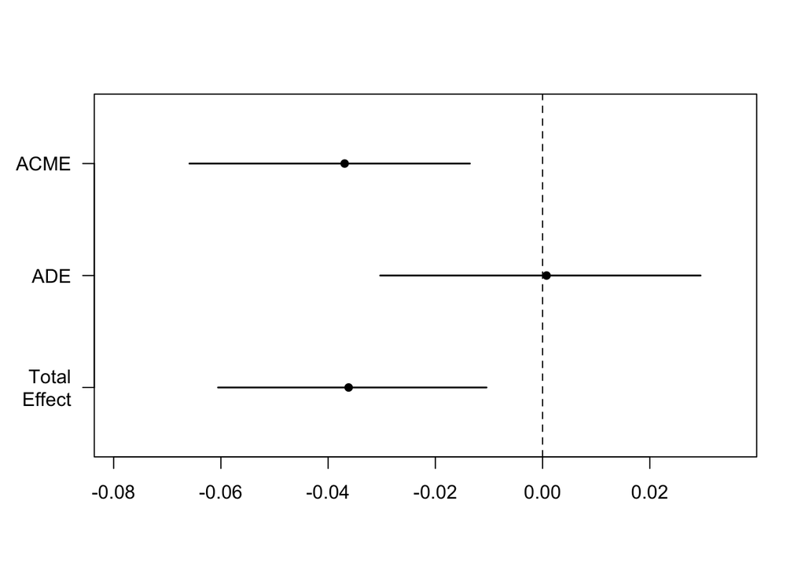

```r
summary(fitMed_result_staph)
```

```
##
## Causal Mediation Analysis
##
## Quasi-Bayesian Confidence Intervals
##
## Mediator Groups: id.x
##
## Outcome Groups: id.x
##
## Output Based on Overall Averages Across Groups
##
##                 Estimate 95% CI Lower 95% CI Upper p-value
## ACME           -0.036914    -0.065859        -0.01  <2e-16 ***
## ADE             0.000743    -0.030282         0.03   0.944
## Total Effect   -0.036171    -0.060527        -0.01   0.008 **
## Prop. Mediated  1.021765     0.348818         3.05   0.008 **
## ---
## Signif. codes:  0 '***' 0.001 '**' 0.01 '*' 0.05 '.' 0.1 ' ' 1
##
## Sample Size Used: 33
##
##
## Simulations: 1000
```

# 7 Staphylococcus abundance in Sputum, mediated by sweat chloride, corrected for id as repeated measure

```r
# Define the dataset and variables
data <- staph_df
mediator <- "chlorid_mmol_cl_l"
outcome <- "Abundance"
predictor <- "delta_ETI_merged"
id_var <- "id.x"
covariates <- c("sex", "age_y")

# Perform the mediation analysis
fitMed_result_staph <- perform_mediation_analysis(data, mediator, outcome, predictor, id_var, covariates)
```

```
## Linear mixed model fit by REML ['lmerMod']
## Formula: chlorid_mmol_cl_l ~ delta_ETI_merged + (1 | id.x) + sex + age_y
##    Data: data
##
## REML criterion at convergence: 286
##
## Scaled residuals:
##      Min       1Q   Median       3Q      Max
## -2.37293 -0.47112  0.02978  0.55453  1.39866
##
## Random effects:
##  Groups   Name        Variance Std.Dev.
##  id.x     (Intercept)  94.59    9.726
##  Residual             350.69   18.727
## Number of obs: 33, groups:  id.x, 18
##
## Fixed effects:
##                  Estimate Std. Error t value
## (Intercept)      70.60303   12.04290   5.863
## delta_ETI_merged -0.06775    0.01366  -4.960
## sex2             16.12357    9.13128   1.766
## age_y            -0.02820    0.40961  -0.069
##
## Correlation of Fixed Effects:
##             (Intr) d_ETI_ sex2
## dlt_ETI_mrg -0.156
## sex2         0.042  0.141
## age_y       -0.860 -0.052 -0.415
## Linear mixed model fit by REML ['lmerMod']
## Formula: Abundance ~ delta_ETI_merged + (1 | id.x) + chlorid_mmol_cl_l +
##     sex + age_y
##    Data: data
##
## REML criterion at convergence: 278.9
##
## Scaled residuals:
##      Min       1Q   Median       3Q      Max
## -1.13413 -0.51388 -0.08702  0.49637  2.11958
##
## Random effects:
```

[output cut: 27 more lines]

```
##
## Output Based on Overall Averages Across Groups
##
##                 Estimate 95% CI Lower 95% CI Upper p-value
## ACME           -0.036750    -0.066039        -0.01   0.002 **
## ADE             0.000385    -0.030117         0.03   0.998
## Total Effect   -0.036364    -0.060417        -0.01   0.008 **
## Prop. Mediated  0.998138     0.343152         3.33   0.010 **
## ---
## Signif. codes:  0 '***' 0.001 '**' 0.01 '*' 0.05 '.' 0.1 ' ' 1
##
## Sample Size Used: 33
##
##
## Simulations: 1000
```

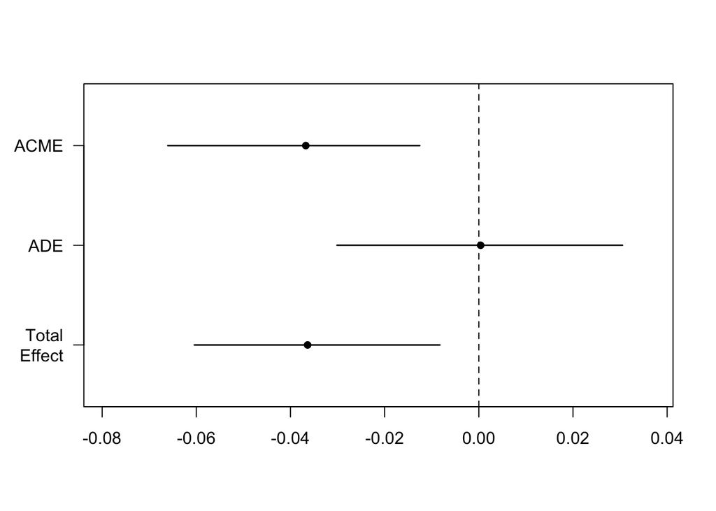

```r
summary(fitMed_result_staph)
```

```
##
## Causal Mediation Analysis
##
## Quasi-Bayesian Confidence Intervals
##
## Mediator Groups: id.x
##
## Outcome Groups: id.x
##
## Output Based on Overall Averages Across Groups
##
##                 Estimate 95% CI Lower 95% CI Upper p-value
## ACME           -0.036750    -0.066039        -0.01   0.002 **
## ADE             0.000385    -0.030117         0.03   0.998
## Total Effect   -0.036364    -0.060417        -0.01   0.008 **
## Prop. Mediated  0.998138     0.343152         3.33   0.010 **
## ---
## Signif. codes:  0 '***' 0.001 '**' 0.01 '*' 0.05 '.' 0.1 ' ' 1
##
## Sample Size Used: 33
##
##
## Simulations: 1000
```

# 8 Test sputum diversity in mediation

```r
alphadiversity_df_sputum <- microbiome::alpha(ps_full_sputum_rar, index = "all")
```

```
## Observed richness
```

```
## Other forms of richness
```

```
## Diversity
```

```
## Evenness
```

```
## Dominance
```

```
## Rarity
```

```r
alphadiversity_df_sputum$x_sample_id <- rownames(alphadiversity_df_sputum)
alphadiversity_df_sputum_sel <- alphadiversity_df_sputum %>%
  dplyr::select(diversity_shannon, observed, evenness_pielou, dominance_dbp, x_sample_id)

ps_full_sputum_df <- as.data.frame(sample_data(ps_full_sputum))

diversity_df_sputum_metadata<- alphadiversity_df_sputum%>%
left_join(ps_full_sputum_df, by = "x_sample_id")

summary(diversity_df_sputum_metadata$diversity_shannon)
```

```
##    Min. 1st Qu.  Median    Mean 3rd Qu.    Max.
##   1.425   2.162   2.815   2.702   3.277   3.895
```

```r
# Define the dataset and variables
data <- diversity_df_sputum_metadata
mediator <- "chlorid_mmol_cl_l"
outcome <- "diversity_shannon"
predictor <- "delta_ETI_merged"
id_var <- "id.x"
covariates <- c("sex", "age_y")

# Perform the mediation analysis for shannon and sweat chloride
fitMed_result_shannon <- perform_mediation_analysis(data, mediator, outcome, predictor, id_var, covariates)
```

```
## Linear mixed model fit by REML ['lmerMod']
## Formula: chlorid_mmol_cl_l ~ delta_ETI_merged + (1 | id.x) + sex + age_y
##    Data: data
##
## REML criterion at convergence: 286
##
## Scaled residuals:
##      Min       1Q   Median       3Q      Max
## -2.37293 -0.47112  0.02978  0.55453  1.39866
##
## Random effects:
##  Groups   Name        Variance Std.Dev.
##  id.x     (Intercept)  94.59    9.726
##  Residual             350.69   18.727
## Number of obs: 33, groups:  id.x, 18
##
## Fixed effects:
##                  Estimate Std. Error t value
## (Intercept)      70.60303   12.04290   5.863
## delta_ETI_merged -0.06775    0.01366  -4.960
## sex2             16.12357    9.13128   1.766
## age_y            -0.02820    0.40961  -0.069
##
## Correlation of Fixed Effects:
##             (Intr) d_ETI_ sex2
## dlt_ETI_mrg -0.156
## sex2         0.042  0.141
## age_y       -0.860 -0.052 -0.415
## Linear mixed model fit by REML ['lmerMod']
## Formula:
## diversity_shannon ~ delta_ETI_merged + (1 | id.x) + chlorid_mmol_cl_l +
##     sex + age_y
##    Data: data
##
## REML criterion at convergence: 83.1
##
## Scaled residuals:
##      Min       1Q   Median       3Q      Max
## -2.12314 -0.46668  0.09151  0.64460  1.02280
##
```

[output cut: 28 more lines]

```
##
## Output Based on Overall Averages Across Groups
##
##                 Estimate 95% CI Lower 95% CI Upper p-value
## ACME            0.000375    -0.000294         0.00   0.262
## ADE             0.000521    -0.000341         0.00   0.276
## Total Effect    0.000895     0.000116         0.00   0.018 *
## Prop. Mediated  0.412006    -0.495239         2.12   0.276
## ---
## Signif. codes:  0 '***' 0.001 '**' 0.01 '*' 0.05 '.' 0.1 ' ' 1
##
## Sample Size Used: 33
##
##
## Simulations: 1000
```

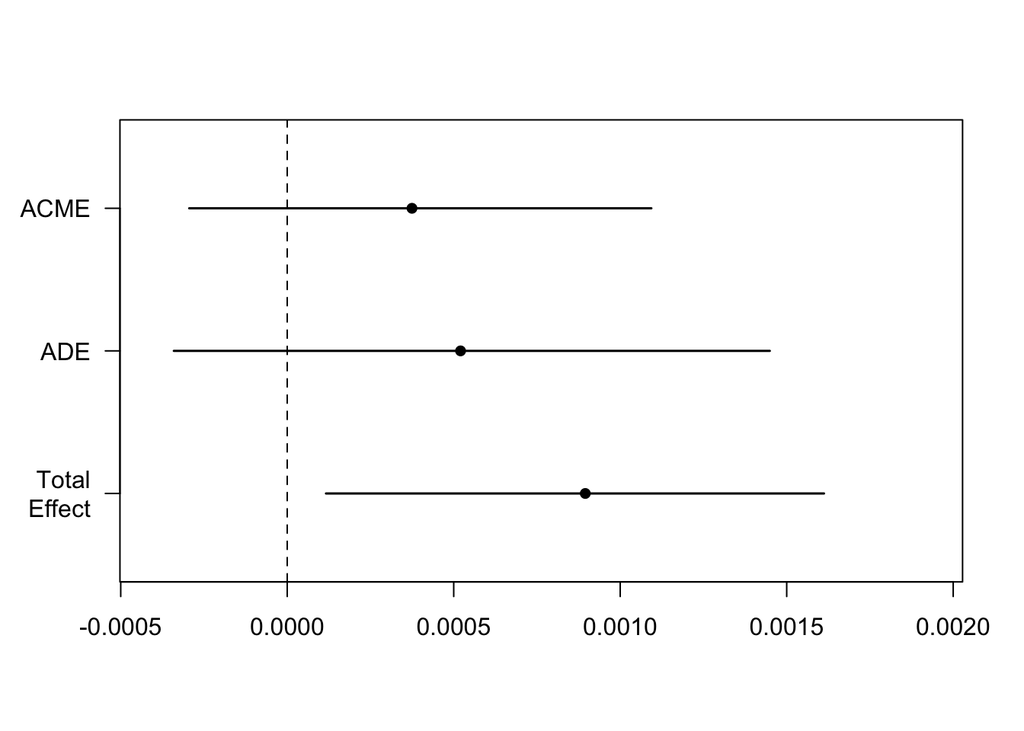

```r
# Perform the mediation analysis for observed and sweat chloride
outcome <- "observed"
fitMed_result_obs <- perform_mediation_analysis(data, mediator, outcome, predictor, id_var, covariates)
```

```
## Linear mixed model fit by REML ['lmerMod']
## Formula: chlorid_mmol_cl_l ~ delta_ETI_merged + (1 | id.x) + sex + age_y
##    Data: data
##
## REML criterion at convergence: 286
##
## Scaled residuals:
##      Min       1Q   Median       3Q      Max
## -2.37293 -0.47112  0.02978  0.55453  1.39866
##
## Random effects:
##  Groups   Name        Variance Std.Dev.
##  id.x     (Intercept)  94.59    9.726
##  Residual             350.69   18.727
## Number of obs: 33, groups:  id.x, 18
##
## Fixed effects:
##                  Estimate Std. Error t value
## (Intercept)      70.60303   12.04290   5.863
## delta_ETI_merged -0.06775    0.01366  -4.960
## sex2             16.12357    9.13128   1.766
## age_y            -0.02820    0.40961  -0.069
##
## Correlation of Fixed Effects:
##             (Intr) d_ETI_ sex2
## dlt_ETI_mrg -0.156
## sex2         0.042  0.141
## age_y       -0.860 -0.052 -0.415
## Linear mixed model fit by REML ['lmerMod']
## Formula: observed ~ delta_ETI_merged + (1 | id.x) + chlorid_mmol_cl_l +
##     sex + age_y
##    Data: data
##
## REML criterion at convergence: 284.1
##
## Scaled residuals:
##      Min       1Q   Median       3Q      Max
## -1.81044 -0.60146  0.02868  0.48516  1.76520
##
## Random effects:
```

[output cut: 27 more lines]

```
##
## Output Based on Overall Averages Across Groups
##
##                Estimate 95% CI Lower 95% CI Upper p-value
## ACME            0.00975     -0.01236         0.03    0.43
## ADE             0.04378      0.00970         0.08    0.01 **
## Total Effect    0.05353      0.02836         0.08  <2e-16 ***
## Prop. Mediated  0.18168     -0.27691         0.73    0.43
## ---
## Signif. codes:  0 '***' 0.001 '**' 0.01 '*' 0.05 '.' 0.1 ' ' 1
##
## Sample Size Used: 33
##
##
## Simulations: 1000
```

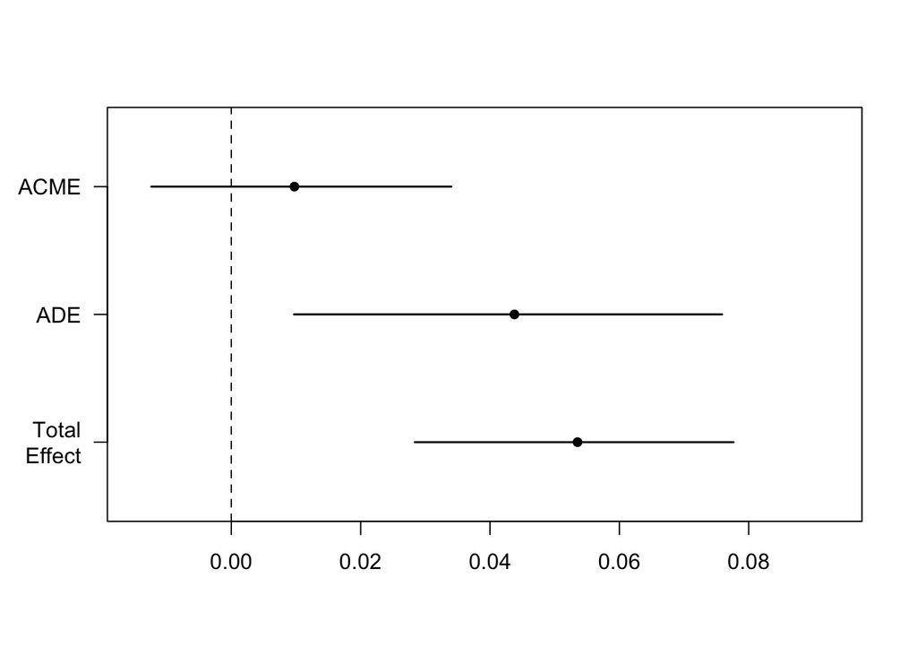

```r
# Perform the mediation analysis for diversity and levofloxacin
diversity_df_sputum_metadata <- diversity_df_sputum_metadata %>%
  mutate(levofloxacin_inhal=case_when(levofloxacin_inhal==0~0, levofloxacin_inhal==2~1))
summary(diversity_df_sputum_metadata$levofloxacin_inhal)
```

```
##    Min. 1st Qu.  Median    Mean 3rd Qu.    Max.
##  0.0000  0.0000  0.0000  0.1228  0.0000  1.0000
```

```r
data <- diversity_df_sputum_metadata
outcome <- "diversity_shannon"
mediator <- "levofloxacin_inhal"
fitMed_result_shannon_levofloxacin <- perform_mediation_analysis(data, mediator, outcome, predictor, id_var, covariates)
```

```
## Linear mixed model fit by REML ['lmerMod']
## Formula: levofloxacin_inhal ~ delta_ETI_merged + (1 | id.x) + sex + age_y
##    Data: data
##
## REML criterion at convergence: -12.9
##
## Scaled residuals:
##     Min      1Q  Median      3Q     Max
## -3.7961 -0.2663 -0.0317  0.2291  4.4827
##
## Random effects:
##  Groups   Name        Variance Std.Dev.
##  id.x     (Intercept) 0.06278  0.2506
##  Residual             0.01226  0.1107
## Number of obs: 57, groups:  id.x, 19
##
## Fixed effects:
##                    Estimate Std. Error t value
## (Intercept)      -3.533e-01  1.634e-01  -2.163
## delta_ETI_merged -1.660e-04  6.765e-05  -2.454
## sex2              4.871e-03  1.267e-01   0.038
## age_y             1.795e-02  5.434e-03   3.304
##
## Correlation of Fixed Effects:
##             (Intr) d_ETI_ sex2
## dlt_ETI_mrg  0.068
## sex2        -0.203  0.101
## age_y       -0.821 -0.196 -0.257
## Linear mixed model fit by REML ['lmerMod']
## Formula:
## diversity_shannon ~ delta_ETI_merged + (1 | id.x) + levofloxacin_inhal +
##     sex + age_y
##    Data: data
##
## REML criterion at convergence: 120.5
##
## Scaled residuals:
##     Min      1Q  Median      3Q     Max
## -2.1402 -0.5878  0.2350  0.6744  1.6051
##
```

[output cut: 28 more lines]

```
##
## Output Based on Overall Averages Across Groups
##
##                Estimate 95% CI Lower 95% CI Upper p-value
## ACME           1.31e-04     2.95e-06          0.0   0.040 *
## ADE            6.87e-04     1.03e-04          0.0   0.020 *
## Total Effect   8.17e-04     2.48e-04          0.0   0.004 **
## Prop. Mediated 1.50e-01     1.87e-03          0.6   0.044 *
## ---
## Signif. codes:  0 '***' 0.001 '**' 0.01 '*' 0.05 '.' 0.1 ' ' 1
##
## Sample Size Used: 57
##
##
## Simulations: 1000
```

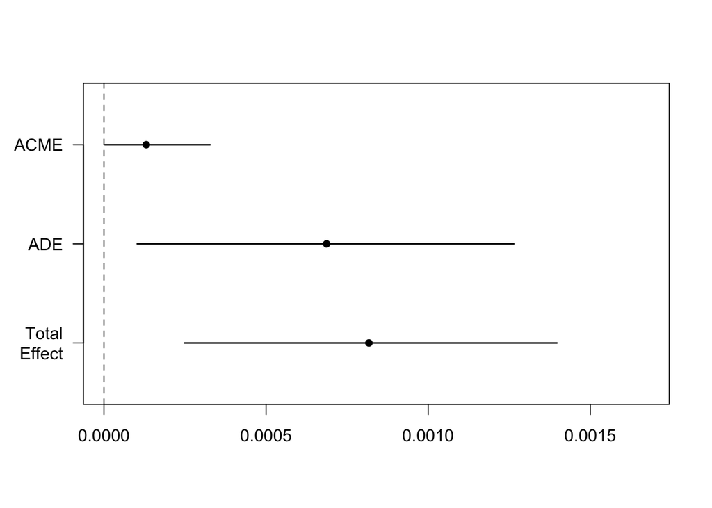